# 10Th Practice ML

- **NBC - Naive Bayes**
- **LDA - Linear Discriminant Analysis** .
- **MLP** - NN classification and regression examples

## Imports

```python
# import numpy, matplotlib, etc.
import numpy as np
import pandas as pd
import seaborn as sns
import plotly.express as px
import matplotlib.pyplot as plt
import plotly.graph_objects as go

# sklearn imports
from sklearn import metrics
from sklearn import pipeline
from sklearn import linear_model
from sklearn import preprocessing
from sklearn import neural_network
from sklearn import model_selection
from sklearn.pipeline import Pipeline
from sklearn.pipeline import make_pipeline
from sklearn.feature_selection import RFECV
from sklearn.compose import ColumnTransformer
from sklearn.linear_model import SGDRegressor
from sklearn.linear_model import SGDClassifier
from sklearn.metrics import mean_squared_error
from sklearn.preprocessing import OneHotEncoder
from sklearn.preprocessing import OrdinalEncoder
from sklearn.preprocessing import StandardScaler
from sklearn.model_selection import GridSearchCV
from sklearn.model_selection import RepeatedKFold
from sklearn.linear_model import LinearRegression
from sklearn.neighbors import KNeighborsClassifier
from sklearn.model_selection import cross_val_score
from sklearn.preprocessing import PolynomialFeatures
from sklearn.model_selection import train_test_split
from sklearn.naive_bayes import GaussianNB
from sklearn.naive_bayes import MultinomialNB
```

## Load SMS dataset

```python
# download sms_spam.csv file from Github
!wget https://raw.githubusercontent.com/stedy/Machine-Learning-with-R-datasets/master/sms_spam.csv
```

```
--2023-06-08 14:29:18--  https://raw.githubusercontent.com/stedy/Machine-Learning-with-R-datasets/master/sms_spam.csv
Resolving raw.githubusercontent.com (raw.githubusercontent.com)... 185.199.108.133, 185.199.109.133, 185.199.110.133, ...
Connecting to raw.githubusercontent.com (raw.githubusercontent.com)|185.199.108.133|:443... connected.
HTTP request sent, awaiting response... 200 OK
Length: 500336 (489K) [text/plain]
Saving to: ‘sms_spam.csv’

sms_spam.csv        100%[===================>] 488.61K  --.-KB/s    in 0.05s

2023-06-08 14:29:18 (10.1 MB/s) - ‘sms_spam.csv’ saved [500336/500336]
```

```python
# load the sms_spam.csv file
sms_df = pd.read_csv('sms_spam.csv')
sms_df
```

|  | type | text |
| --- | --- | --- |
| 0 | ham | Go until jurong point, crazy.. Available only ... |
| 1 | ham | Ok lar... Joking wif u oni... |
| 2 | spam | Free entry in 2 a wkly comp to win FA Cup fina... |
| 3 | ham | U dun say so early hor... U c already then say... |
| 4 | ham | Nah I don't think he goes to usf, he lives aro... |
| ... | ... | ... |
| 5569 | spam | This is the 2nd time we have tried 2 contact u... |
| 5570 | ham | Will ü b going to esplanade fr home? |
| 5571 | ham | Pity, * was in mood for that. So...any other s... |
| 5572 | ham | The guy did some bitching but I acted like i'd... |
| 5573 | ham | Rofl. Its true to its name |

5574 rows × 2 columns

```python
# show sms_df info
sms_df.info()
```

```
<class 'pandas.core.frame.DataFrame'>
RangeIndex: 5574 entries, 0 to 5573
Data columns (total 2 columns):
 #   Column  Non-Null Count  Dtype
---  ------  --------------  -----
 0   type    5574 non-null   object
 1   text    5574 non-null   object
dtypes: object(2)
memory usage: 87.2+ KB
```

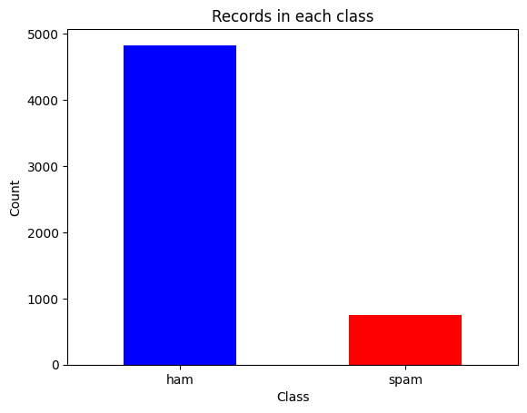

```python
count_classes = sms_df['type'].value_counts()
plt.title("Records in each class")
count_classes.plot(kind='bar', color=['b', 'r'])
plt.xticks(rotation='horizontal')
plt.xlabel("Class")
plt.ylabel("Count")
plt.show()
```

```python
#value counts
print(sms_df['type'].value_counts())
#ratio of classes
print(sms_df['type'].value_counts(normalize=True))
```

```
ham     4827
spam     747
Name: type, dtype: int64
ham     0.865985
spam    0.134015
Name: type, dtype: float64
```

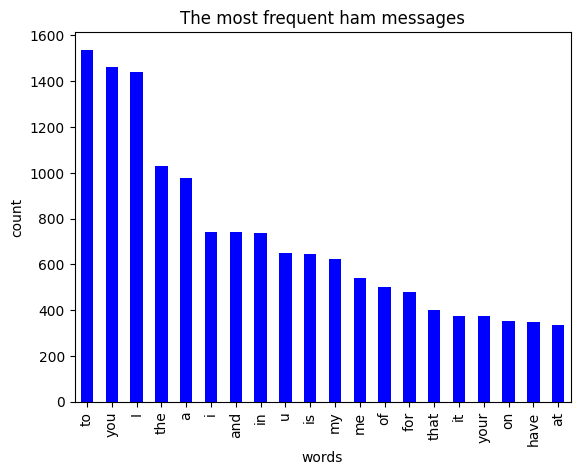

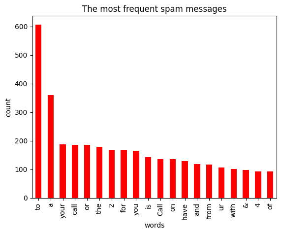

```python
from collections import Counter
def plot_most_common(count, class_name, color):
    # count frequency of each word in each class
    count_res = Counter(" ".join(sms_df[sms_df["type"]==class_name]["text"]).split()).most_common(count)
    # convert to dataframe
    df_count = pd.DataFrame.from_dict(count_res)
    # rename columns
    df_count = df_count.rename(columns={0: class_name, 1 : "count"})

    # draw bar plot
    df_count.plot(kind='bar', color=color, legend=False)
    x = np.arange(len(df_count[class_name]))
    plt.xticks(x, df_count[class_name])
    plt.title('The most frequent ' + class_name + ' messages')
    plt.xlabel('words')
    plt.ylabel('count')


# call the function twice (for 'ham' and 'spam' classes respectively)
plot_most_common(20, 'ham', 'b')
plot_most_common(20, 'spam', 'r')
plt.show()
```

## Vectorizer

```python
from sklearn.feature_extraction.text import CountVectorizer
vectorizer = CountVectorizer()
messages = ['Hi there, I love Afeka college 2023','Hi there, I love HIT college 2023']
v = vectorizer.fit_transform(messages)
_df = pd.DataFrame(v.toarray(), columns=vectorizer.get_feature_names_out())
_df
```

|  | 2023 | afeka | college | hi | hit | love | there |
| --- | --- | --- | --- | --- | --- | --- | --- |
| 0 | 1 | 1 | 1 | 1 | 0 | 1 | 1 |
| 1 | 1 | 0 | 1 | 1 | 1 | 1 | 1 |

```python
# stop words
vectorizer = CountVectorizer(stop_words = 'english')
messages = ['Hi there, I love Afeka college 2023','Hi there, I love HIT college 2023']
v = vectorizer.fit_transform(messages)
_df = pd.DataFrame(v.toarray(), columns=vectorizer.get_feature_names_out())
_df
```

|  | 2023 | afeka | college | hi | hit | love |
| --- | --- | --- | --- | --- | --- | --- |
| 0 | 1 | 1 | 1 | 1 | 0 | 1 |
| 1 | 1 | 0 | 1 | 1 | 1 | 1 |

## Remove stop words

```python
#Convert a collection of text documents to a matrix of token counts.
vectorizer = CountVectorizer(stop_words = 'english')
X = vectorizer.fit_transform(sms_df["text"])
```

```python
# convert to array
X = X.toarray()
# check size of X
X.shape
```

```
(5574, 8444)
```

```python
X[:5]
```

```
array([[0, 0, 0, ..., 0, 0, 0],
       [0, 0, 0, ..., 0, 0, 0],
       [0, 0, 0, ..., 0, 0, 0],
       [0, 0, 0, ..., 0, 0, 0],
       [0, 0, 0, ..., 0, 0, 0]])
```

```python
sms_df["type"] = sms_df["type"].map({'ham':'not_spam','spam':'spam'})
sms_df
```

|  | type | text |
| --- | --- | --- |
| 0 | not_spam | Go until jurong point, crazy.. Available only ... |
| 1 | not_spam | Ok lar... Joking wif u oni... |
| 2 | spam | Free entry in 2 a wkly comp to win FA Cup fina... |
| 3 | not_spam | U dun say so early hor... U c already then say... |
| 4 | not_spam | Nah I don't think he goes to usf, he lives aro... |
| ... | ... | ... |
| 5569 | spam | This is the 2nd time we have tried 2 contact u... |
| 5570 | not_spam | Will ü b going to esplanade fr home? |
| 5571 | not_spam | Pity, * was in mood for that. So...any other s... |
| 5572 | not_spam | The guy did some bitching but I acted like i'd... |
| 5573 | not_spam | Rofl. Its true to its name |

5574 rows × 2 columns

```python
sms_df['type'].value_counts()
```

```
not_spam    4827
spam         747
Name: type, dtype: int64
```

```python
sms_df['type'].value_counts(normalize=True)
```

```
not_spam    0.865985
spam        0.134015
Name: type, dtype: float64
```

```python
# split dataset to train and validadtion data
X_train, X_test, t_train, t_test = train_test_split(X,  sms_df['type'],  test_size = 0.2,  random_state = 21)
```

```python
from sklearn.preprocessing import MinMaxScaler
scaler = MinMaxScaler(feature_range = (0, 1))
X_train = scaler.fit_transform(X_train.copy())
X_test = scaler.fit_transform(X_test.copy())
```

```python
print(f'X train')
print(X_train)
print()
print(f'X test')
print(X_test)
print()
print(f'y train')
print(t_train)
print()
print(f'y test')
print(t_test)
print()
```

```
X train
[[0. 0. 0. ... 0. 0. 0.]
 [0. 0. 0. ... 0. 0. 0.]
 [0. 0. 0. ... 0. 0. 0.]
 ...
 [0. 0. 0. ... 0. 0. 0.]
 [0. 0. 0. ... 0. 0. 0.]
 [0. 0. 0. ... 0. 0. 0.]]

X test
[[0. 0. 0. ... 0. 0. 0.]
 [0. 0. 0. ... 0. 0. 0.]
 [0. 0. 0. ... 0. 0. 0.]
 ...
 [0. 0. 0. ... 0. 0. 0.]
 [0. 0. 0. ... 0. 0. 0.]
 [0. 0. 0. ... 0. 0. 0.]]

y train
1199    not_spam
4339    not_spam
4021    not_spam
1860    not_spam
2651    not_spam
          ...
4706    not_spam
1144    not_spam
48      not_spam
772     not_spam
5327    not_spam
Name: type, Length: 4459, dtype: object

y test
5178    not_spam
5399    not_spam
3570    not_spam
4919    not_spam
5079        spam
          ...
990     not_spam
1585    not_spam
2877    not_spam
2562    not_spam
3922    not_spam
Name: type, Length: 1115, dtype: object
```

```python
from sklearn.metrics import recall_score, precision_score
from sklearn.metrics import confusion_matrix

def display_train_val_cms(title, t_train,t_test,y_train,y_test):
                                           # True , Pred

    cm_train = confusion_matrix(t_train, y_train)
    cm_test = confusion_matrix(t_test, y_test)
    cm_train_norm = confusion_matrix(t_train, y_train, normalize='true')
    cm_test_norm = confusion_matrix(t_test, y_test, normalize='true')
    cm_train_df_norm = pd.DataFrame(cm_train_norm,index=['actual_not_spam', 'actual_spam'],columns=['predicted_not_spam', 'predicted_spam'])
    cm_test_df_norm = pd.DataFrame(cm_test_norm,index=['actual_not_spam', 'actual_spam'],columns=['predicted_not_spam', 'predicted_spam'])
    cm_train_df = pd.DataFrame(cm_train,index=['actual_not_spam', 'actual_spam'],columns=['predicted_not_spam', 'predicted_spam'])
    cm_test_df = pd.DataFrame(cm_test,index=['actual_not_spam', 'actual_spam'],columns=['predicted_not_spam', 'predicted_spam'])
    recall_precision_train = f'Recall = {recall_score(t_train,y_train,pos_label="spam"):.3f} ,Precision = {precision_score(t_train,y_train,pos_label="spam"):.3f}'
    recall_precision_test = f'Recall = {recall_score(t_test,y_test,pos_label="spam"):.3f} , Precision = {precision_score(t_test,y_test,pos_label="spam"):.3f}'
    sns.set(font_scale=2)
    fig = plt.figure(figsize = (30,12))
    fig.suptitle(title,fontsize=32)

    ax1 = fig.add_subplot(221)
    sns.heatmap(cm_train_df, annot=True, cmap=plt.cm.Pastel1, fmt='g')
    ax1.title.set_text(f"Train: {recall_precision_train}")

    ax2 = fig.add_subplot(222)
    sns.heatmap(cm_test_df, annot=True, cmap=plt.cm.Pastel2, fmt='g')
    ax2.title.set_text(f"Test: {recall_precision_test}")

    ax3 = fig.add_subplot(223)
    sns.heatmap(cm_train_df_norm, annot=True, cmap=plt.cm.Pastel1, fmt='g')

    ax4 = fig.add_subplot(224)
    sns.heatmap(cm_test_df_norm, annot=True, cmap=plt.cm.Pastel2, fmt='g')
    plt.show()
```

## Model 1 : Logistic Regression Classifier

```
Test counter = Counter({'not_spam': 989, 'spam': 126})
Spam / Not spam ratio on test:  SPAM=0.12914798206278028, NOT_SPAM=0.8708520179372198
```

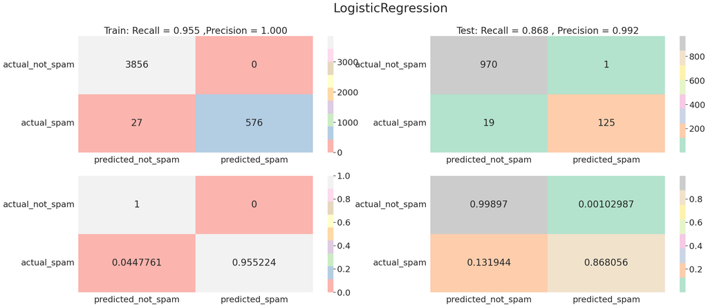

```python
from sklearn.linear_model import LogisticRegression
clf = LogisticRegression()
clf.fit(X_train,t_train)
y_train = clf.predict(X_train)
y_test = clf.predict(X_test)
print(f'Test counter = {Counter(y_test)}')
_c = Counter(t_test)
total = sum(_c.values(), 0.0)
for key in _c:
  _c[key] /= total
print(f'Spam / Not spam ratio on test:  SPAM={_c["spam"]}, NOT_SPAM={_c["not_spam"]}')
display_train_val_cms('LogisticRegression', t_train,t_test, y_train,y_test)
```

## NBC (Naive Bayes)

[Naive Bayes](https://scikit-learn.org/stable/modules/naive_bayes.html#naive-bayes) methods are:

- a set of supervised learning algorithms based on applying **Bayes’ theorem** with the **"naive" assumption** of conditional independence between every pair of features given the value of the class variable.
- Bayes’ theorem states the following relationship: given class variable `y` and dependent feature vector `x1` through `xn`:

[figure not shown]

- Using the naive conditional independence assumption that:

[figure not shown]

- for all `i`, this relationship is simplified to:

[figure not shown]

- Since `P(x1,...,xn)` is constant given the input, we can use the following classification rule:

[figure not shown]

We can use [Maximum A Posteriori (MAP) estimation](https://en.wikipedia.org/wiki/Maximum_a_posteriori_estimation) to estimate `P(y)` and `P(xi|y)` ; the former is then the relative frequency of class in the training set.

- **Different naive Bayes classifiers differ mainly by the assumptions they make regarding the distribution of `P(xi|y)`**.
- In spite of their apparently over-simplified assumptions, **naive Bayes classifiers** have **worked quite well** in many real-world situations, famously **document classification and spam filtering**.
- **They require a small amount of training data to estimate the necessary parameters** (for theoretical reasons why naive Bayes works well, and on which types of data it does, see [The Optimality of Naive Bayes](https://www.cs.unb.ca/~hzhang/publications/FLAIRS04ZhangH.pdf)).
- Naive Bayes learners and classifiers **can be extremely fast** **compared** to more **sophisticated methods**.
- The decoupling of the class conditional feature distributions means that each distribution can be independently estimated as a one-dimensional distribution.  
  This in turn helps to alleviate problems stemming from the curse of dimensionality.
- On the other side, although naive Bayes is known as a decent classifier, **it is known to be a bad estimator**, **so the probability outputs from `predict_proba` are not to be taken too seriously**.

### Bayes Theorem : Basics

Bayes’ Theorem states the following for any two events A and B:

**P(A|B) = P(A)*P(B|A) / P(B)**

where:

- P(A|B): The probability of event A, given event B has occurred.
- P(B|A): The probability of event B, given event A has occurred.
- P(A): The probability of event A.
- P(B): The probability of event B.

For example, suppose the probability of the weather being cloudy is 40%.

Also suppose the probability of rain on a given day is 20%.

Also suppose the probability of clouds on a rainy day is 85%.

If it’s cloudy outside on a given day, what is the probability that it will rain that day?

### Solution

- P(rain | cloudy) = P(rain) * P(cloudy | rain) / P(cloudy)
- P(rain | cloudy) = 0.20 * 0.85 / 0.40
- P(rain | cloudy) = 0.425

Question :

Suppose we know the following probabilities:

- P(rain) = 0.20
- P(cloudy) = 0.40
- P(cloudy | rain) = 0.85

**Calculate : p(rain | cloudy)**

```python
def bayesTheorem(pA,pB, pBA):
  return pA*pBA / pB


pRain = 0.2
pCloudy = 0.4
pCloudyRain = 0.85

bayesTheorem(pRain,pCloudy, pCloudyRain)
```

```
0.425
```

### Model 2 : NBC - MultinomialNB

```
Test counter = Counter({'not_spam': 973, 'spam': 142})
Spam / Not spam ratio on test:  SPAM=0.12914798206278028, NOT_SPAM=0.8708520179372198
```

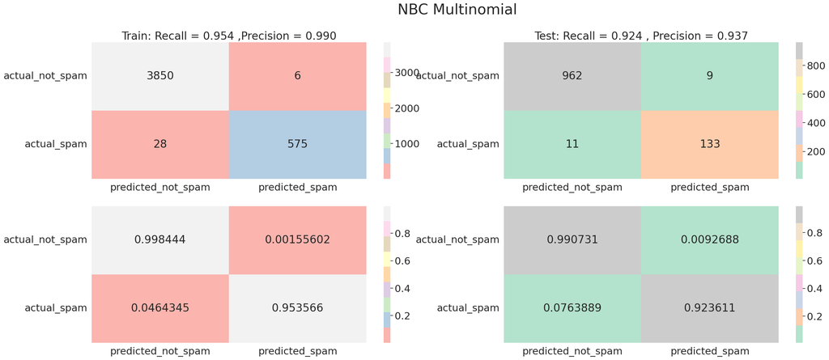

```python
#create NB multinomial model
model = MultinomialNB()
model.fit(X_train,y_train)
y_train = model.predict(X_train)
y_test = model.predict(X_test)
print(f'Test counter = {Counter(y_test)}')
_c = Counter(t_test)
total = sum(_c.values(), 0.0)
for key in _c:
  _c[key] /= total
print(f'Spam / Not spam ratio on test:  SPAM={_c["spam"]}, NOT_SPAM={_c["not_spam"]}')
display_train_val_cms('NBC Multinomial',t_train,t_test, y_train,y_test)
```

### Model 3 : NBC - GaussianNB

```
Test counter = Counter({'not_spam': 868, 'spam': 247})
Spam / Not spam ratio on test:  SPAM=0.12914798206278028, NOT_SPAM=0.8708520179372198
```

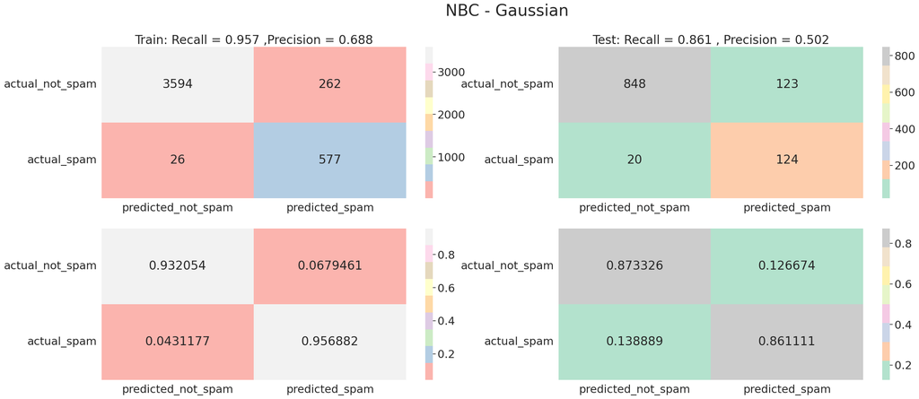

```python
#create Gaussian model (demonstration for unsuitable model)
model = GaussianNB()
model.fit(X_train,y_train)
y_train = model.predict(X_train)
y_test = model.predict(X_test)
print(f'Test counter = {Counter(y_test)}')
_c = Counter(t_test)
total = sum(_c.values(), 0.0)
for key in _c:
  _c[key] /= total
print(f'Spam / Not spam ratio on test:  SPAM={_c["spam"]}, NOT_SPAM={_c["not_spam"]}')

display_train_val_cms('NBC - Gaussian', t_train,t_test, y_train,y_test)
```

## LDA (Linear Discriminant Analysis) and QDA (Quadratic Discriminant Analysis)

When using NBC, we need to work with ordinal features.  
In NBC we calculate the posterior `P(xi|y)` for each feature value with counting (number of samples with this feature value divided by the number of samples of the category).  
In [Linear and Quadratic Discriminant Analysis](https://scikit-learn.org/stable/modules/lda_qda.html#linear-and-quadratic-discriminant-analysis) we can use numerical features too.  
We calculate the posterior `P(xi|y)` for numerical feature values with density function.

Both LDA and QDA can be derived from simple probabilistic models that model the class conditional distribution of the data `P(X|y=k)` for each class `k`.  
Predictions can then be obtained by using Bayes’ rule, for each training sample `x`.

[figure not shown]

We select the class 'k' which maximizes this posterior probability.  
More specifically, for linear and quadratic discriminant analysis `P(x|y)` is modeled as a multivariate Gaussian distribution with density:

[figure not shown]

Where `d` is the number of features.

LDA is a special case of QDA, where the Gaussians for each class are assumed to share the same covariance matrix.

LDA can only learn linear boundaries, while QDA can learn quadratic boundaries and is, therefore, more flexible.

[figure not shown]

## **MLP - Multi-layer Perceptron** **Classification + Feature Creation:**

Another way of getting more features is by using [NN](https://scikit-learn.org/stable/modules/neural_networks_supervised.html) (Neural Networks).  
In our case, we will use Scikit-learn MLPClassifier (MLP is Multi-layer Perceptron).  
It is a neural network that looks something like that:

[figure not shown]

In the middle, there can be any number of layers.  
From the left side, we push the input features, and from the right side, we are getting our result (In our case the classification result).  
The more layers, the more calculated features there are for the model to learn.  
Neural Networks are transforming features into other features.  
The new feature dimension can be bigger or smaller than the original dimension.  
If we want to keep the original features in addition to the new features, we need to do something called bypass (you will learn more about it in the NN class). We need to be careful not to get to overfitting (too many features can cause that).

Weighted sum example

[figure not shown]

```python
from sklearn import datasets
data_dict = datasets.load_iris()
iris_df = pd.DataFrame(data=data_dict['data'],columns=data_dict['feature_names'])
iris_df['class'] = data_dict['target']
iris_df
```

|  | sepal length (cm) | sepal width (cm) | petal length (cm) | petal width (cm) | class |
| --- | --- | --- | --- | --- | --- |
| 0 | 5.1 | 3.5 | 1.4 | 0.2 | 0 |
| 1 | 4.9 | 3.0 | 1.4 | 0.2 | 0 |
| 2 | 4.7 | 3.2 | 1.3 | 0.2 | 0 |
| 3 | 4.6 | 3.1 | 1.5 | 0.2 | 0 |
| 4 | 5.0 | 3.6 | 1.4 | 0.2 | 0 |
| ... | ... | ... | ... | ... | ... |
| 145 | 6.7 | 3.0 | 5.2 | 2.3 | 2 |
| 146 | 6.3 | 2.5 | 5.0 | 1.9 | 2 |
| 147 | 6.5 | 3.0 | 5.2 | 2.0 | 2 |
| 148 | 6.2 | 3.4 | 5.4 | 2.3 | 2 |
| 149 | 5.9 | 3.0 | 5.1 | 1.8 | 2 |

150 rows × 5 columns

```python
t = iris_df['class']
X = iris_df.drop('class', axis=1)
X_train, X_test, t_train, t_test = model_selection.train_test_split(X, t, test_size=0.25, random_state=2)
```

### Compare with LogisticRegression

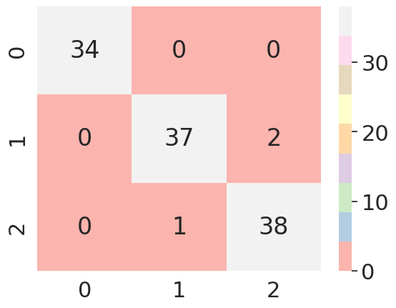

```python
clf = LogisticRegression(max_iter=10000)
clf.fit(X_train,t_train)
y_train = clf.predict(X_train)
y_val = clf.predict(X_test)
cm_train = confusion_matrix(t_train, y_train)
cm_val = confusion_matrix(t_test, y_val)
sns.heatmap(cm_train, annot=True, cmap=plt.cm.Pastel1, fmt='g')
```

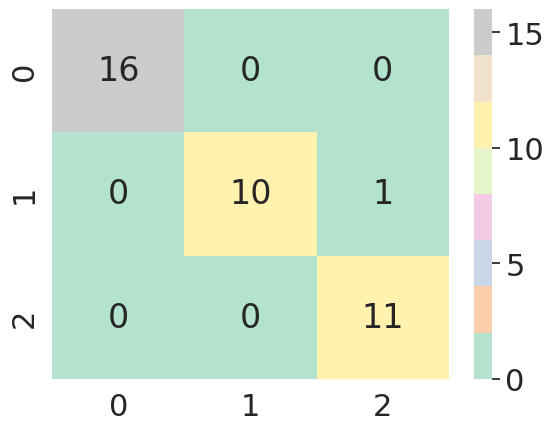

```python
sns.heatmap(cm_val, annot=True, cmap=plt.cm.Pastel2, fmt='g')
```

```python
from sklearn.metrics import accuracy_score, precision_score, recall_score, f1_score

print('Accuracy: {:.2f}\n'.format(accuracy_score(t_train, y_train)))
```

```
Accuracy: 0.97
```

### Review hidden layers size

```python
# import neural_network and run MLP on the data
from sklearn import neural_network
for i in [4,10,50,100]:
  clf = neural_network.MLPClassifier(activation='logistic',
                                     solver='sgd',
                                     hidden_layer_sizes=(i,),
                                     max_iter=10000,
                                     random_state=42)
  clf.fit(X_train, t_train)
  print(f'-----nodes in hidden layer {i}-----')
  y_train_prob = clf.predict_proba(X_train)
  y_test_prob = clf.predict_proba(X_test)
  y_train = clf.predict(X_train)
  y_test = clf.predict(X_test)
  train_score = clf.score(X_train, t_train)
  test_score = clf.score(X_test, t_test)
  ce_train = metrics.log_loss(t_train, y_train_prob)
  ce_test = metrics.log_loss(t_test, y_test_prob)
  cm_train = confusion_matrix(t_train, y_train)
  cm_test = confusion_matrix(t_test, y_test)
  print(f'Accuracy score on train {train_score}')
  print(f'Accuracy score on test {test_score}')
  print()
  print(f'CE on train {ce_train}')
  print(f'CE on test {ce_test}')
  print()
  print(cm_train)
  print()
  print(cm_test)
```

```
-----nodes in hidden layer 4-----
Accuracy score on train 0.35714285714285715
Accuracy score on test 0.34210526315789475

CE on train 1.1146712619105619
CE on test 1.1610728402163468

[[ 0 34  0]
 [ 0  1 38]
 [ 0  0 39]]

[[ 0 15  1]
 [ 0  2  9]
 [ 0  0 11]]
-----nodes in hidden layer 10-----
Accuracy score on train 0.9642857142857143
Accuracy score on test 0.9473684210526315

CE on train 0.44617443602994744
CE on test 0.40628410660347797

[[34  0  0]
 [ 0 35  4]
 [ 0  0 39]]

[[16  0  0]
 [ 0  9  2]
 [ 0  0 11]]
-----nodes in hidden layer 50-----
Accuracy score on train 0.9732142857142857
Accuracy score on test 0.9736842105263158

CE on train 0.3486185048963124
CE on test 0.31913607434274416

[[34  0  0]
 [ 0 36  3]
 [ 0  0 39]]

[[16  0  0]
 [ 0 10  1]
 [ 0  0 11]]
-----nodes in hidden layer 100-----
Accuracy score on train 0.9821428571428571
Accuracy score on test 0.9736842105263158

CE on train 0.3241401674096162
CE on test 0.29698830089164946

[[34  0  0]
 [ 0 37  2]
 [ 0  0 39]]

[[16  0  0]
 [ 0 10  1]
 [ 0  0 11]]
```

### Add hidden layer

```python
# import neural_network and run MLP on the data
from sklearn import neural_network
for i in [4,10,50,100]:
  clf = neural_network.MLPClassifier(activation='logistic',
                                     solver='sgd',
                                     hidden_layer_sizes=(i,i),
                                     max_iter=10000,random_state=42)
  clf.fit(X_train, t_train)
  print(f'-----nodes in hidden layer {i,i}-----')
  y_train_prob = clf.predict_proba(X_train)
  y_test_prob = clf.predict_proba(X_test)
  y_train = clf.predict(X_train)
  y_test = clf.predict(X_test)
  train_score = clf.score(X_train, t_train)
  test_score = clf.score(X_test, t_test)
  ce_train = metrics.log_loss(t_train, y_train_prob)
  ce_test = metrics.log_loss(t_test, y_test_prob)
  cm_train = confusion_matrix(t_train, y_train)
  cm_test = confusion_matrix(t_test, y_test)
  print(f'Accuracy score on train {train_score}')
  print(f'Accuracy score on test {test_score}')
  print()
  print(f'CE on train {ce_train}')
  print(f'CE on test {ce_test}')
  print()
  print(cm_train)
  print()
  print(cm_test)
```

```
-----nodes in hidden layer (4, 4)-----
Accuracy score on train 0.3482142857142857
Accuracy score on test 0.2894736842105263

CE on train 1.102300973668974
CE on test 1.1176921618309341

[[ 0 34  0]
 [ 0 39  0]
 [ 0 39  0]]

[[ 0 16  0]
 [ 0 11  0]
 [ 0 11  0]]
-----nodes in hidden layer (10, 10)-----
Accuracy score on train 0.3482142857142857
Accuracy score on test 0.2894736842105263

CE on train 1.0944521132350873
CE on test 1.1295920424668011

[[ 0 34  0]
 [ 0  0 39]
 [ 0  0 39]]

[[ 0 16  0]
 [ 0  0 11]
 [ 0  0 11]]
-----nodes in hidden layer (50, 50)-----
Accuracy score on train 0.3482142857142857
Accuracy score on test 0.2894736842105263

CE on train 1.1000491080604318
CE on test 1.116043970987102

[[ 0 34  0]
 [ 0 39  0]
 [ 0 39  0]]

[[ 0 16  0]
 [ 0 11  0]
 [ 0 11  0]]
-----nodes in hidden layer (100, 100)-----
Accuracy score on train 0.35714285714285715
Accuracy score on test 0.2894736842105263

CE on train 1.0962412796555754
CE on test 1.119713728467304

[[ 0 34  0]
 [ 0 39  0]
 [ 0 38  1]]

[[ 0 16  0]
 [ 0 11  0]
 [ 0 11  0]]
```

### Optimize learning rate

```python
# import neural_network and run MLP on the data
from sklearn import neural_network
for i in [4,10,50,100]:
  clf = neural_network.MLPClassifier(activation='logistic',
                                     solver='sgd',
                                     hidden_layer_sizes=(i,i),
                                     max_iter=10000,random_state=42,
                                     learning_rate='constant',
                                     learning_rate_init=0.1)
  clf.fit(X_train, t_train)
  print(f'-----nodes in hidden layer {i,i}-----')
  y_train_prob = clf.predict_proba(X_train)
  y_test_prob = clf.predict_proba(X_test)
  y_train = clf.predict(X_train)
  y_test = clf.predict(X_test)
  train_score = clf.score(X_train, t_train)
  test_score = clf.score(X_test, t_test)
  ce_train = metrics.log_loss(t_train, y_train_prob)
  ce_test = metrics.log_loss(t_test, y_test_prob)
  cm_train = confusion_matrix(t_train, y_train)
  cm_test = confusion_matrix(t_test, y_test)
  print(f'Accuracy score on train {train_score}')
  print(f'Accuracy score on test {test_score}')
  print()
  print(f'CE on train {ce_train}')
  print(f'CE on test {ce_test}')
  print()
  print(cm_train)
  print()
  print(cm_test)
```

```
-----nodes in hidden layer (4, 4)-----
Accuracy score on train 0.9732142857142857
Accuracy score on test 1.0

CE on train 0.07439397898322753
CE on test 0.05925642993717336

[[34  0  0]
 [ 0 37  2]
 [ 0  1 38]]

[[16  0  0]
 [ 0 11  0]
 [ 0  0 11]]
-----nodes in hidden layer (10, 10)-----
Accuracy score on train 0.9732142857142857
Accuracy score on test 1.0

CE on train 0.07042827947796818
CE on test 0.05641620920420916

[[34  0  0]
 [ 0 37  2]
 [ 0  1 38]]

[[16  0  0]
 [ 0 11  0]
 [ 0  0 11]]
-----nodes in hidden layer (50, 50)-----
Accuracy score on train 0.9910714285714286
Accuracy score on test 1.0

CE on train 0.06265898752950656
CE on test 0.04658360802916397

[[34  0  0]
 [ 0 38  1]
 [ 0  0 39]]

[[16  0  0]
 [ 0 11  0]
 [ 0  0 11]]
-----nodes in hidden layer (100, 100)-----
Accuracy score on train 0.9910714285714286
Accuracy score on test 1.0

CE on train 0.06024116077064763
CE on test 0.045151290651587746

[[34  0  0]
 [ 0 38  1]
 [ 0  0 39]]

[[16  0  0]
 [ 0 11  0]
 [ 0  0 11]]
```

## MLP Regressor (Boston Housing)

```python
# load dataset directly from web using the following link :
boston_df = pd.read_csv("https://raw.githubusercontent.com/selva86/datasets/master/BostonHousing.csv")
boston_df.reset_index(drop=True, inplace=True)
display(boston_df)
```

|  | crim | zn | indus | chas | nox | rm | age | dis | rad | tax | ptratio | b | lstat | medv |
| --- | --- | --- | --- | --- | --- | --- | --- | --- | --- | --- | --- | --- | --- | --- |
| 0 | 0.00632 | 18.0 | 2.31 | 0 | 0.538 | 6.575 | 65.2 | 4.0900 | 1 | 296 | 15.3 | 396.90 | 4.98 | 24.0 |
| 1 | 0.02731 | 0.0 | 7.07 | 0 | 0.469 | 6.421 | 78.9 | 4.9671 | 2 | 242 | 17.8 | 396.90 | 9.14 | 21.6 |
| 2 | 0.02729 | 0.0 | 7.07 | 0 | 0.469 | 7.185 | 61.1 | 4.9671 | 2 | 242 | 17.8 | 392.83 | 4.03 | 34.7 |
| 3 | 0.03237 | 0.0 | 2.18 | 0 | 0.458 | 6.998 | 45.8 | 6.0622 | 3 | 222 | 18.7 | 394.63 | 2.94 | 33.4 |
| 4 | 0.06905 | 0.0 | 2.18 | 0 | 0.458 | 7.147 | 54.2 | 6.0622 | 3 | 222 | 18.7 | 396.90 | 5.33 | 36.2 |
| ... | ... | ... | ... | ... | ... | ... | ... | ... | ... | ... | ... | ... | ... | ... |
| 501 | 0.06263 | 0.0 | 11.93 | 0 | 0.573 | 6.593 | 69.1 | 2.4786 | 1 | 273 | 21.0 | 391.99 | 9.67 | 22.4 |
| 502 | 0.04527 | 0.0 | 11.93 | 0 | 0.573 | 6.120 | 76.7 | 2.2875 | 1 | 273 | 21.0 | 396.90 | 9.08 | 20.6 |
| 503 | 0.06076 | 0.0 | 11.93 | 0 | 0.573 | 6.976 | 91.0 | 2.1675 | 1 | 273 | 21.0 | 396.90 | 5.64 | 23.9 |
| 504 | 0.10959 | 0.0 | 11.93 | 0 | 0.573 | 6.794 | 89.3 | 2.3889 | 1 | 273 | 21.0 | 393.45 | 6.48 | 22.0 |
| 505 | 0.04741 | 0.0 | 11.93 | 0 | 0.573 | 6.030 | 80.8 | 2.5050 | 1 | 273 | 21.0 | 396.90 | 7.88 | 11.9 |

506 rows × 14 columns

```python
# detach the target values from the input data
t = boston_df['medv']
X = boston_df.drop('medv', axis=1)
print('X')
display(X)
print()
print('t')
display(t)
```

```
X
```

|  | crim | zn | indus | chas | nox | rm | age | dis | rad | tax | ptratio | b | lstat |
| --- | --- | --- | --- | --- | --- | --- | --- | --- | --- | --- | --- | --- | --- |
| 0 | 0.00632 | 18.0 | 2.31 | 0 | 0.538 | 6.575 | 65.2 | 4.0900 | 1 | 296 | 15.3 | 396.90 | 4.98 |
| 1 | 0.02731 | 0.0 | 7.07 | 0 | 0.469 | 6.421 | 78.9 | 4.9671 | 2 | 242 | 17.8 | 396.90 | 9.14 |
| 2 | 0.02729 | 0.0 | 7.07 | 0 | 0.469 | 7.185 | 61.1 | 4.9671 | 2 | 242 | 17.8 | 392.83 | 4.03 |
| 3 | 0.03237 | 0.0 | 2.18 | 0 | 0.458 | 6.998 | 45.8 | 6.0622 | 3 | 222 | 18.7 | 394.63 | 2.94 |
| 4 | 0.06905 | 0.0 | 2.18 | 0 | 0.458 | 7.147 | 54.2 | 6.0622 | 3 | 222 | 18.7 | 396.90 | 5.33 |
| ... | ... | ... | ... | ... | ... | ... | ... | ... | ... | ... | ... | ... | ... |
| 501 | 0.06263 | 0.0 | 11.93 | 0 | 0.573 | 6.593 | 69.1 | 2.4786 | 1 | 273 | 21.0 | 391.99 | 9.67 |
| 502 | 0.04527 | 0.0 | 11.93 | 0 | 0.573 | 6.120 | 76.7 | 2.2875 | 1 | 273 | 21.0 | 396.90 | 9.08 |
| 503 | 0.06076 | 0.0 | 11.93 | 0 | 0.573 | 6.976 | 91.0 | 2.1675 | 1 | 273 | 21.0 | 396.90 | 5.64 |
| 504 | 0.10959 | 0.0 | 11.93 | 0 | 0.573 | 6.794 | 89.3 | 2.3889 | 1 | 273 | 21.0 | 393.45 | 6.48 |
| 505 | 0.04741 | 0.0 | 11.93 | 0 | 0.573 | 6.030 | 80.8 | 2.5050 | 1 | 273 | 21.0 | 396.90 | 7.88 |

506 rows × 13 columns

```
t
```

```
0      24.0
1      21.6
2      34.7
3      33.4
4      36.2
       ...
501    22.4
502    20.6
503    23.9
504    22.0
505    11.9
Name: medv, Length: 506, dtype: float64
```

```python
X_train, X_test, t_train, t_test = model_selection.train_test_split(X, t,
                                                                    test_size=0.2,
                                                                    random_state=2)
```

```python
# fit a linear model.
NE_reg = linear_model.LinearRegression().fit(X_train, t_train)
# calculate score for each group
print('R2 score on train',NE_reg.score(X_train, t_train))
print('R2 score on test',NE_reg.score(X_test, t_test))
y_train = NE_reg.predict(X_train)
y_test = NE_reg.predict(X_test)
print()
print('RMSE on train',metrics.mean_squared_error(t_train, y_train, squared=False))
print('RMSE on test',metrics.mean_squared_error(t_test, y_test, squared=False))
```

```
R2 score on train 0.7285831776605591
R2 score on test 0.7789207451814409

RMSE on train 4.791001312472465
RMSE on test 4.300630200615773
```

```python
from sklearn import neural_network
reg = neural_network.MLPRegressor(activation='logistic',
                                    solver='lbfgs',
                                    hidden_layer_sizes=(64,32),
                                    max_iter=10000,random_state=42,
                                    alpha=0.0001,
                                    learning_rate_init=0.001)
reg.fit(X_train, t_train)

y_train = reg.predict(X_train)
y_test = reg.predict(X_test)
print(f'R2 Score train : {reg.score(X_train,t_train)}')
print(f'R2 Score test : {reg.score(X_test,t_test)}')

print('RMSE on train',metrics.mean_squared_error(t_train, y_train, squared=False))
print('RMSE on test',metrics.mean_squared_error(t_test, y_test, squared=False))
```

```
R2 Score train : 0.5787683207027979
R2 Score test : 0.5633697504971471
RMSE on train 5.9685443012974675
RMSE on test 6.043868608835151
```

[Activation functions](https://www.youtube.com/watch?v=m0pIlLfpXWE) In artificial neural networks, the activation function of a node defines the output of that node given an input or set of inputs.

[figure not shown]

```python
from sklearn import neural_network
reg = neural_network.MLPRegressor(activation='relu',
                                    solver='lbfgs',
                                    hidden_layer_sizes=(64,32,),
                                    max_iter=10000,random_state=42,
                                    alpha=0.0001,
                                    learning_rate_init=0.001)
reg.fit(X_train, t_train)

y_train = reg.predict(X_train)
y_test = reg.predict(X_test)
print(f'R2 Score train : {reg.score(X_train,t_train)}')
print(f'R2 Score test : {reg.score(X_test,t_test)}')

print('RMSE on train',metrics.mean_squared_error(t_train, y_train, squared=False))
print('RMSE on test',metrics.mean_squared_error(t_test, y_test, squared=False))
```

```
R2 Score train : 0.935444531897633
R2 Score test : 0.7925494434283235
RMSE on train 2.3365464888096823
RMSE on test 4.165962981477622
```

# Decision Trees

Decision Trees (DTs) are a non-parametric supervised learning method used for classification and regression.  
The goal is to create a model that predicts the value of a target variable by learning simple decision rules inferred from the data features.

For instance, in the example below, decision trees learn from data to approximate a sine curve with a set of if-then-else decision rules.  
The deeper the tree, the more complex the decision rules and the fitter the model (may cause over-fitting):

[figure not shown]

### Metrics

When using decision trees, we use heuristics to decide which node will be next.  
Our objective function is to maximize the metric at each split (the IG - Information Gain).

#### IG (Information Gain)

IG is defined as:

[figure not shown]

where `f` is the feature to perform the split, and `Dp` and `Dj` are the datasets of the parent and jth child node, respectively.  
`I` is the impurity measure (Entropy or Gini).  
`N` is the total number of samples, and `Nj` is the number of samples at the jth child node.

We may use two matrics as `I`:

1. Entropy
2. Gini

#### Entropy

Entorpy is defined as:

[figure not shown]

`p(i|t)` is the proportion of the samples that belong to class `i` for a particular node `t`.  
The entropy is therefore 0 if all samples at a node belong to the same class, and the Entropy is maximal if we have a uniform class distribution.

#### Gini

Gini is defined as:

[figure not shown]

Similar to the Entropy, the Gini Impurity is maximal if the classes are perfectly mixed.

#### Comparison

[figure not shown]

In practice, both Gini Impurity and Entropy typically yield very similar results and it is often not worth spending much time on evaluating trees using different impurity criteria rather than experimenting with different pruning cut-offs.

### Some advantages of decision trees are:

- Simple to understand and to interpret. Trees can be visualized.
- Requires little data preparation.
- The cost of using the tree (i.e., predicting data) is logarithmic in the number of data points used to train the tree (the tree height).
- Able to handle both numerical and categorical data.
- Able to handle multi-output problems.
- Uses a white-box model. If a given situation is observable in a model, the explanation for the condition is easily explained by boolean logic. By contrast, in a black-box model (e.g., in an artificial neural network), results may be more difficult to interpret.

### The disadvantages of decision trees include:

- Decision-tree learners can create over-complex trees that do not generalize the data well. This is called overfitting. Mechanisms such as pruning, setting the minimum number of samples required at a leaf node, or setting the maximum depth of the tree are necessary to avoid this problem.
- Decision trees can be unstable because small variations in the data might result in a completely different tree being generated. This problem is mitigated by using decision trees within an ensemble.
- Predictions of decision trees are neither smooth nor continuous, but piecewise constant approximations as seen in the above figure. Therefore, they are not good at extrapolation.
- The problem of learning an optimal decision tree is known to be NP-complete under several aspects of optimality and even for simple concepts. Consequently, practical decision-tree learning algorithms are based on heuristic algorithms such as the greedy algorithm where locally optimal decisions are made at each node. Such algorithms cannot guarantee to return the globally optimal decision tree. This can be mitigated by training multiple trees in an ensemble learner, where the features and samples are randomly sampled with replacement.
- Decision tree learners create biased trees if some classes dominate. It is therefore recommended to balance the dataset before fitting with the decision tree.

Let's use Scikit-learn [DecisionTreeClassifier](https://scikit-learn.org/stable/modules/generated/sklearn.tree.DecisionTreeClassifier.html).

## Random Forest

The fundamental idea behind a random forest is to combine many decision trees into a single model.  
A random forest is a meta estimator that fits a number of decision tree classifiers on various sub-samples of the dataset and uses averaging to improve the predictive accuracy and control over-fitting.  
Individually, predictions made by decision trees may not be accurate but combined together, the predictions will be closer to the mark on average.

Each decision tree in the forest considers a random subset of features and only has access to a random set of the training data points (Bootstrap).  
Each decision tree in the forest may have a maximum depth.

[figure not shown]

Let's use Scikit-learn [RandomForestClassifier](https://scikit-learn.org/stable/modules/generated/sklearn.ensemble.RandomForestClassifier.html).

```python
from sklearn import datasets
data_dict = datasets.load_iris()
df = pd.DataFrame(data=data_dict['data'],columns=data_dict['feature_names'])
df['class'] = data_dict['target']
df
```

|  | sepal length (cm) | sepal width (cm) | petal length (cm) | petal width (cm) | class |
| --- | --- | --- | --- | --- | --- |
| 0 | 5.1 | 3.5 | 1.4 | 0.2 | 0 |
| 1 | 4.9 | 3.0 | 1.4 | 0.2 | 0 |
| 2 | 4.7 | 3.2 | 1.3 | 0.2 | 0 |
| 3 | 4.6 | 3.1 | 1.5 | 0.2 | 0 |
| 4 | 5.0 | 3.6 | 1.4 | 0.2 | 0 |
| ... | ... | ... | ... | ... | ... |
| 145 | 6.7 | 3.0 | 5.2 | 2.3 | 2 |
| 146 | 6.3 | 2.5 | 5.0 | 1.9 | 2 |
| 147 | 6.5 | 3.0 | 5.2 | 2.0 | 2 |
| 148 | 6.2 | 3.4 | 5.4 | 2.3 | 2 |
| 149 | 5.9 | 3.0 | 5.1 | 1.8 | 2 |

150 rows × 5 columns

```python
import sklearn.datasets as datasets
from sklearn.model_selection import train_test_split
from sklearn.tree import DecisionTreeClassifier
from sklearn.metrics import accuracy_score, roc_auc_score, roc_curve
from sklearn.tree import plot_tree

from sklearn.tree import DecisionTreeClassifier
from sklearn.model_selection import GridSearchCV, RandomizedSearchCV

from sklearn.metrics import confusion_matrix
from sklearn.metrics import classification_report
```

```python
q1 = df['sepal width (cm)'].quantile(0.25)
q3 = df['sepal width (cm)'].quantile(0.75)
iqr = q3 - q1
df = df[(df['sepal width (cm)'] >= q1-1.5*iqr) & (df['sepal width (cm)'] <= q3+1.5*iqr)]
```

```python
t = iris_df['class']
X = iris_df.drop('class', axis=1)
X_train, X_test, t_train, t_test = model_selection.train_test_split(X, t, test_size=0.25, random_state=2)
```

```python
dt = DecisionTreeClassifier(max_depth=3, min_samples_leaf=10, random_state=42 )
dt.fit(X_train, t_train)
```

```
DecisionTreeClassifier(max_depth=3, min_samples_leaf=10, random_state=42)
```

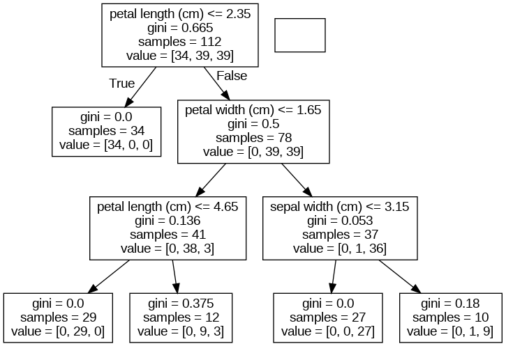

```python
from IPython.display import Image
from sklearn.tree import export_graphviz

#!pip install pydotplus
import pydotplus


features = X.columns
dot_data = export_graphviz(dt, out_file=None, feature_names=features)
graph = pydotplus.graph_from_dot_data(dot_data)
Image(graph.create_png())
```

```python
#dt = DecisionTreeClassifier(random_state=1)
#dt.fit(X_train, t_train)

y_pred_train = dt.predict(X_train)
y_pred = dt.predict(X_test)
y_prob = dt.predict_proba(X_test)
```

```python
print('Accuracy of Decision Tree-Train: ', accuracy_score(y_pred_train, t_train))
print('Accuracy of Decision Tree-Test: ', accuracy_score(y_pred, t_test))
```

```
Accuracy of Decision Tree-Train:  0.9642857142857143
Accuracy of Decision Tree-Test:  0.9473684210526315
```

```python
print('Confusion Matrix - Train:','\n',confusion_matrix(t_train,y_pred_train))
print('\n','Confusion Matrix - Test:','\n',confusion_matrix(t_test,y_pred))
```

```
Confusion Matrix - Train:
 [[34  0  0]
 [ 0 38  1]
 [ 0  3 36]]

 Confusion Matrix - Test:
 [[16  0  0]
 [ 0 10  1]
 [ 0  1 10]]
```

```python
print(classification_report(t_test,y_pred))
```

```
              precision    recall  f1-score   support

           0       1.00      1.00      1.00        16
           1       0.91      0.91      0.91        11
           2       0.91      0.91      0.91        11

    accuracy                           0.95        38
   macro avg       0.94      0.94      0.94        38
weighted avg       0.95      0.95      0.95        38
```

```python
dt = DecisionTreeClassifier(random_state=42)

params = {'max_depth' : [2,3,4,5],
        'min_samples_split': [2,3,4,5],
        'min_samples_leaf': [1,2,3,4,5]}

gsearch = GridSearchCV(dt, param_grid=params, cv=3)

gsearch.fit(X_train,t_train)

gsearch.best_params_
```

```
{'max_depth': 3, 'min_samples_leaf': 4, 'min_samples_split': 2}
```

```python
# Passing best parameter for the Hyperparameter Tuning
dt = DecisionTreeClassifier(**gsearch.best_params_, random_state=42)

dt.fit(X_train, t_train)

y_pred_train = dt.predict(X_train)
y_prob_train = dt.predict_proba(X_train)[:,1]

y_pred = dt.predict(X_test)
y_prob = dt.predict_proba(X_test)[:,1]
```

```python
print('Accuracy of Decision Tree-Train: ', accuracy_score(y_pred_train, t_train))
print('Accuracy of Decision Tree-Test: ', accuracy_score(y_pred, t_test))
```

```
Accuracy of Decision Tree-Train:  0.9821428571428571
Accuracy of Decision Tree-Test:  0.9736842105263158
```

```python
print('Confusion Matrix - Train:','\n',confusion_matrix(t_train,y_pred_train))
print('\n','Confusion Matrix - Test:','\n',confusion_matrix(t_test,y_pred))
```

```
Confusion Matrix - Train:
 [[34  0  0]
 [ 0 37  2]
 [ 0  0 39]]

 Confusion Matrix - Test:
 [[16  0  0]
 [ 0 10  1]
 [ 0  0 11]]
```

```python
print(classification_report(t_test,y_pred))
```

```
              precision    recall  f1-score   support

           0       1.00      1.00      1.00        16
           1       1.00      0.91      0.95        11
           2       0.92      1.00      0.96        11

    accuracy                           0.97        38
   macro avg       0.97      0.97      0.97        38
weighted avg       0.98      0.97      0.97        38
```

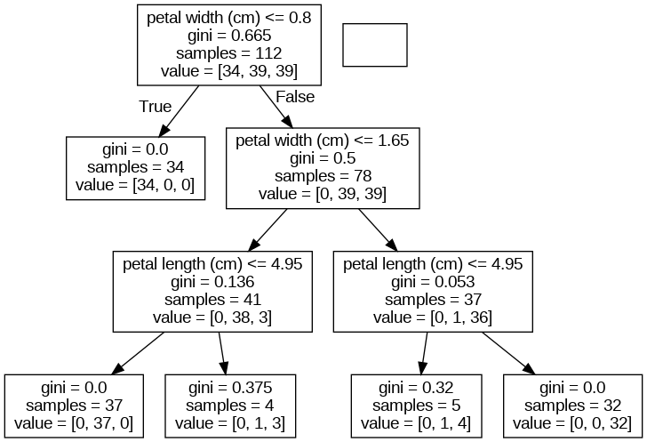

```python
features = X.columns
dot_data = export_graphviz(dt, out_file=None, feature_names=features)
graph = pydotplus.graph_from_dot_data(dot_data)
Image(graph.create_png())
```

```python
cross_val_score(DecisionTreeClassifier(**gsearch.best_params_, random_state=42),X_train,t_train, cv=3).mean()
```

```
0.9554291133238503
```

```python
# show accuracy of random forest classifier on data
from sklearn.ensemble import RandomForestClassifier
#{'max_depth': 3, 'min_samples_leaf': 4, 'min_samples_split': 2}
print('RandomForestClassifier score:',
      cross_val_score(
          RandomForestClassifier(random_state=42, max_depth=34,min_samples_leaf=4,min_samples_split=2),
           X_train,t_train, cv=3).mean())
```

```
RandomForestClassifier score: 0.9556661925082978
```